# IODS course project

As said lets continue with previous model. Here is some visual comparison of the real observation and the data from the model.

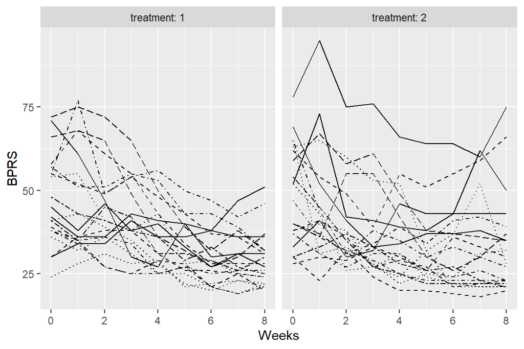

```r
ggplot(BPRSL, aes(x = week, y = bprs, linetype = subject)) +
  geom_line() +
  scale_x_continuous(name = "Weeks") +
  scale_y_continuous(name = "BPRS") +
  theme(legend.position = "none") +
  scale_linetype_manual(values = rep(1:10, times=4)) +
  facet_grid(. ~ treatment, labeller = label_both)
```

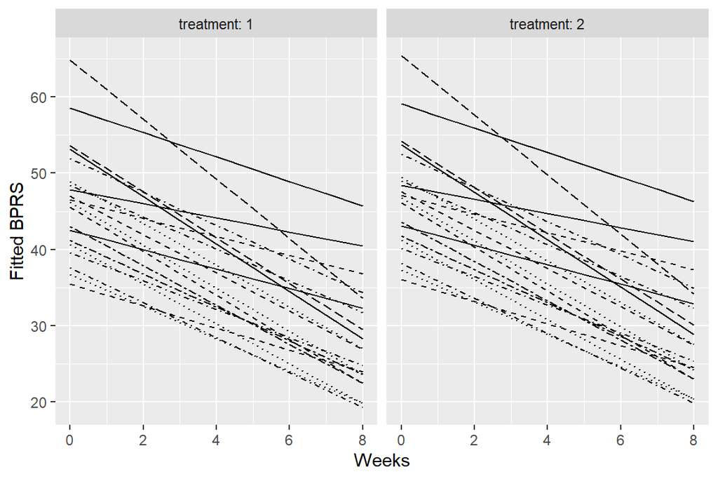

```r
Fitted <- fitted(refmod2)
BPRSL <- BPRSL %>% mutate(fitted = Fitted)

ggplot(BPRSL, aes(x = week, y = Fitted, linetype = subject)) +
  geom_line() +
  scale_x_continuous(name = "Weeks") +
  scale_y_continuous(name = "Fitted BPRS") +
  theme(legend.position = "none") +
  scale_linetype_manual(values = rep(1:10, times=4)) +
  facet_grid(. ~ treatment, labeller = label_both)
```

The lines are showing similar kind of changes that can be seen in the real data. This is defenately better model than the first one, as it doesn’t allow slope randomness meaning that all the lines are parallel. Also, third model dont cahnge a thing compared to this second one. Always need to remember that this is just a model, and that exact fit is impossible to get.

Thanks for the grat course!!

Back to top